# Practical Machine Learning Project

Steven Myers

September 17, 2017

## Introduction

Using devices such as Jawbone Up, Nike FuelBand, and Fitbit it is now possible to collect a large amount of data about personal activity relatively inexpensively. These type of devices are part of the quantified self movement - a group of enthusiasts who take measurements about themselves regularly to improve their health, to find patterns in their behavior, or because they are tech geeks.

One thing that people regularly do is quantify how much of a particular activity they do, but they rarely quantify how well they do it. In this project, your goal will be to use data from accelerometers on the belt, forearm, arm, and dumbell of 6 participants. They were asked to perform barbell lifts correctly and incorrectly in 5 different ways.

The goal of this project is to predict the manner in which they did the exercise. This is the “classe” variable in the training set.

The information is available from the website here: http://groupware.les.inf.puc-rio.br/har

## Load Packages and Data Preparation

```r
library(caret)
library(rattle)
library(rpart)
library(rpart.plot)
library(randomForest)
library(repmis)
library(corrplot)


download.file('https://d396qusza40orc.cloudfront.net/predmachlearn/pml-training.csv','pml-training.csv' )
download.file('https://d396qusza40orc.cloudfront.net/predmachlearn/pml-testing.csv','pml-testing.csv')

trainingset <- read.csv('pml-training.csv',
                     header = TRUE,
                     sep = ",",
                     na.strings = c("NA", "#DIV/0!"))

testingset <- read.csv('pml-testing.csv',
                     header = TRUE,
                     sep = ",",
                     na.strings = c("NA", "#DIV/0!"))
```

## Subsetting the Data

```r
CorrectSensor <- grepl("classe|belt|arm|dumbell", names(trainingset))

trainset <- trainingset[,CorrectSensor]
testset <- testingset[,CorrectSensor]

colswithoutna = colSums(is.na(trainset)) == 0
trainset <- trainset[,colswithoutna]
testset <- testset[,colswithoutna]
```

## Visualize the Correlations

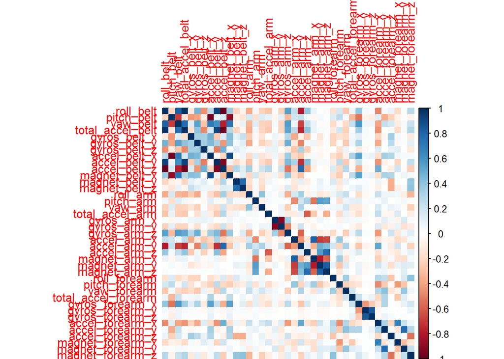

## Slicing the training data set

```r
set.seed(20102)
inTrain <- createDataPartition(trainset$classe, p=0.75, list=F)
trainset <- trainset[inTrain, ]
testtrainset <- trainset[-inTrain, ]
```

## Modeling the Data

We will do a random forest model with this data. This is the best model for our situation because will automatically choose the important variables for us while also controlling for outliers and correlated variables. I will do a 3-fold cross validation when applying this algorithm.

```r
RandomForestControl <- trainControl(method="cv", 3)
RandomForestModel <- train(classe ~ ., data=trainset, method="rf", trControl=RandomForestControl, ntree=200)
RandomForestModel
```

[output not shown]

```r
RandomForestPredict <- predict(RandomForestModel, testtrainset)


acc <- postResample(RandomForestPredict, testtrainset$classe)
acc
```

```
## Accuracy    Kappa
##        1        1
```

```r
outofsampleerror <- 1 - as.numeric(confusionMatrix(testtrainset$classe, RandomForestPredict)$overall[1])
outofsampleerror
```

```
## [1] 0
```

[output not shown]

[output not shown]

## Predicting the Test Set

Now I’ll apply the model to the original testing data set.

```r
result <- predict(RandomForestModel, testset)

result
```

```
##  [1] B A B A A E D B A A B C B A E E A B B B
## Levels: A B C D E
```

## Visualization of the Model

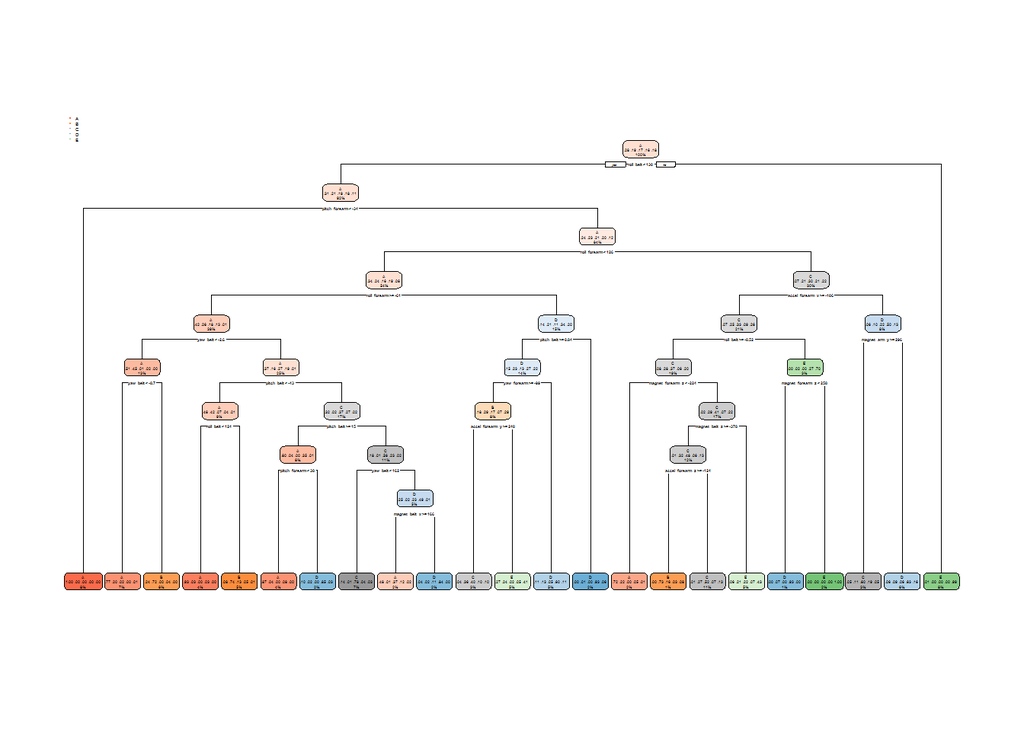

```r
treeModel <- rpart(classe ~ ., data=trainset, method="class")
rpart.plot(treeModel) # fast plot
```